Voltar

# 🎮 Análise Econômica do Mercado de Consoles 1

Eduardo Birchal, Enzo Braz, Gabriel Guimarães, João Smolinski

Um mergulho quantitativo na indústria que une paixão por games, ciência de dados e economia

## 📚 Contexto e Motivação

Como entusiastas de jogos e estudantes de ciência de dados, sempre nos intrigou a complexidade por trás do mercado de jogos e dos consoles. Como fatores como preço, custo de produção e estratégia corporativa impactam esse ecossistema?

Este trabalho nasceu da nossa curiosidade em decifrar as **dinâmicas econômicas dos videogames**, combinando:

- Nossa paixão pessoal por jogos
- Dados históricos de vendas
- Estimativas técnicas de custos
- Relatórios estratégicos do setor

## 🔍 Fontes de Dados

### Principais Bases:

- **[VGChartz:](https://www.vgchartz.com/)** Histórico completo de vendas semanais
- **[Kaggle:](https://www.kaggle.com/)** Metadados técnicos dos consoles
- **Estimativas de Custo e Análises:** Bloomberg, IHS Markit, iFixit, The Verge, WSJ, TechInsights

## ⏳ Séries Temporais de Vendas

Esta seção tem o intuito de analisar os dados das séries temporais de vendas de todos os consoles de 2004 até 2025. Todo o conteúdo aboradado até o momento aqui se baseia na decomposição vetorial da serie em partes sazionais, tendências e resíduos.

As próximas células são simples, uma de imports do python, ou seja, as bibliotecas usadas para fazer os cálculos necessários, e a outra a criação dos objetos de manipulação das séries temporais. Além disso, é colocado uma breve vizualização de todas as séries de cada console coexistindo. Veja abaixo:

```python
import pandas as pd #dataframes
    import matplotlib.pyplot as plt #plot
    import numpy as np #manipulação de vetores
    from datetime import datetime #TAD dados temporais
    import scipy.stats #biblioteca para estatísticas básicas
    from statsmodels.tsa.seasonal import STL #decomposição da série
```

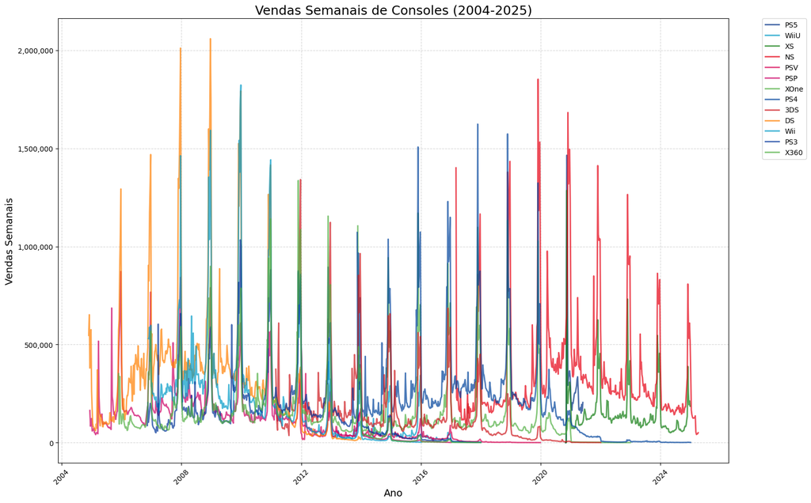

```python
df = pd.read_csv('../data/console_weekly_sales.csv')

    df['week'] = pd.to_datetime(df['week'])

    consoles = ['PS5', 'WiiU', 'XS', 'NS', 'PSV', 'PSP', 'XOne', 'PS4', '3DS', 'DS', 'Wii', 'PS3', 'X360']
    colors = ['#003087', '#009AC7', '#107C10', '#e60012', '#d70051', '#cc0066', '#52b043', '#00439c', '#ce181e', '#ff7f00', '#009ac7', '#003399', '#52b043']

    plt.figure(figsize=(16, 10))

    for console, color in zip(consoles, colors):
        console_data = df[df['console'] == console]

        plt.plot(console_data['week'], console_data['sales'],
                 label=console, color=color, alpha=0.7, linewidth=2)

    plt.title('Vendas Semanais de Consoles (2004-2025)', fontsize=18)
    plt.xlabel('Ano', fontsize=14)
    plt.ylabel('Vendas Semanais', fontsize=14)
    plt.grid(True, linestyle='--', alpha=0.5)

    plt.legend(bbox_to_anchor=(1.05, 1), loc='upper left', borderaxespad=0., fontsize=10)

    plt.gca().yaxis.set_major_formatter(plt.FuncFormatter(lambda x, loc: "{:,}".format(int(x))))
    plt.xticks(rotation=45)

    plt.tight_layout()

    plt.show()
```

### Tall-Thin Matriz

Para facilitar as operações, separa os vetores antes condeçados, a forma que conseguimos extrair eles, para uma matriz onde cada coluna é um vetor. A ideia é de expandir isso posteriormente, assim verificando qual console se relaciona mais com qual, correlações, e outras propriedades vetorias entre console. Sendo assim, se cria uma matriz **M = n + x + p . . .** , como:

```python
consoles = ['PS5', 'XS', 'NS', 'PSV', 'XOne', 'PS4', 'WiiU','3DS', 'PS3', 'X360', 'Wii', 'PSP'] #except for WiiU
    consoles.reverse()
    last_console = df[df['console'] == 'DS'].set_index("week").rename(columns={"sales" : 'DS'}).get(['DS'])
    for console in consoles:
        console_data = df[df['console'] == console].set_index("week").rename(columns={"sales" : console}).get([console])
        last_console = pd.concat([last_console,console_data], axis=1).fillna(0)

    last_console.to_csv('../data/console_matrix.csv',index=True)
    last_console
```

| week | DS | PSP | Wii | X360 | PS3 | 3DS | WiiU | PS4 | XOne | PSV | NS | XS | PS5 |
| --- | --- | --- | --- | --- | --- | --- | --- | --- | --- | --- | --- | --- | --- |
| 2004-11-27 | 546507.0 | 0.0 | 0.0 | 0.0 | 0.0 | 0.0 | 0.0 | 0.0 | 0.0 | 0.0 | 0.0 | 0.0 | 0.0 |
| 2004-12-04 | 651898.0 | 0.0 | 0.0 | 0.0 | 0.0 | 0.0 | 0.0 | 0.0 | 0.0 | 0.0 | 0.0 | 0.0 | 0.0 |
| 2004-12-11 | 379673.0 | 163812.0 | 0.0 | 0.0 | 0.0 | 0.0 | 0.0 | 0.0 | 0.0 | 0.0 | 0.0 | 0.0 | 0.0 |
| 2004-12-18 | 441085.0 | 83598.0 | 0.0 | 0.0 | 0.0 | 0.0 | 0.0 | 0.0 | 0.0 | 0.0 | 0.0 | 0.0 | 0.0 |
| 2004-12-25 | 575947.0 | 98771.0 | 0.0 | 0.0 | 0.0 | 0.0 | 0.0 | 0.0 | 0.0 | 0.0 | 0.0 | 0.0 | 0.0 |
| ... | ... | ... | ... | ... | ... | ... | ... | ... | ... | ... | ... | ... | ... |
| 2025-03-08 | 0.0 | 0.0 | 0.0 | 0.0 | 0.0 | 0.0 | 0.0 | 0.0 | 0.0 | 0.0 | 53393.0 | 0.0 | 0.0 |
| 2025-03-15 | 0.0 | 0.0 | 0.0 | 0.0 | 0.0 | 0.0 | 0.0 | 0.0 | 0.0 | 0.0 | 41164.0 | 0.0 | 0.0 |
| 2025-03-22 | 0.0 | 0.0 | 0.0 | 0.0 | 0.0 | 0.0 | 0.0 | 0.0 | 0.0 | 0.0 | 44383.0 | 0.0 | 0.0 |
| 2025-03-29 | 0.0 | 0.0 | 0.0 | 0.0 | 0.0 | 0.0 | 0.0 | 0.0 | 0.0 | 0.0 | 44591.0 | 0.0 | 0.0 |
| 2025-04-05 | 0.0 | 0.0 | 0.0 | 0.0 | 0.0 | 0.0 | 0.0 | 0.0 | 0.0 | 0.0 | 50300.0 | 0.0 | 0.0 |

2277 rows × 13 columns

### Análise de Série Temporal

Por fim, chegamos na parte principal, a de análises das séries tempo. Inicialmente, fazemos uma limpeza dos dados, afim de obter uma função simples que retire os zeros dos nossos vetores para que não tenhamos que considerar em nível de programação todos os anos existentes, tal como:

```python
df = pd.read_csv('../data/console_matrix.csv', parse_dates=['week'], index_col='week')

    consoles = df.columns[1:]
    df[consoles] = df[consoles].replace(0, float('nan'))
```

```python
consoles = ['PS5', 'WiiU', 'XS', 'NS', 'PSV', 'PSP', 'XOne', 'PS4', '3DS', 'DS', 'Wii', 'PS3', 'X360']
```

### Seasonal and Trend with LOESS (STL)

```
Para os pesos de na regressão
```

$$ W(u) = \begin{pmatrix} (1 - u^3)^3 \\ 0 \end{pmatrix} \quad \text{se } 0 \leqslant u < 1, \quad \text{e } \mathbf{0} \text{ caso contrário.} $$

```
Para os valores esperados
```

$$ v_i(x) = W\left(\frac{|x_i - x|}{\lambda_g(x)}\right) $$

Assim se coloca os valores esperados em cada momento, restando então decompor isto nas três partes, que seguem pelo processo iterativo, começando com a tendência $T(t)^0$ em um valor arbitrário (que se converge conforme a função de erro da regressão), e a sazionalidade $S(t)^0$ em 0. Indo assim iterativamente: $$ \begin{aligned} T_t^{(k)} &= \text{LOESS}\left(Y_t - S_t^{(k-1)}\right) \\ S_t^{(k)} &= \text{LOESS}\left(\text{Médias sazonais de } Y_t - T_t^{(k)}\right) \end{aligned} $$

Já os resíduos é $R(t) = V(t) - T(t)- S(t)$.

Por fim, para verificar a qualidade dos dados previstos, pode aproximar pela métrica $R$, tal que R é dado por $$ R^2 = 1 - \frac{\sum_{i=1}^{n} (y_i - \hat{y}_i)^2}{\sum_{i=1}^{n} (y_i - \bar{y})^2} $$

### Interpretação dos Componentes Decompostos

O próximo passo então e entender como isto tudo se correlaciona com o mercado e vendas de consoles, para isso dispõe dos tópicos:

#### 1. Tendência (Tₜ)

- **O que representa**: A evolução de **longo prazo** das vendas, indicando períodos de crescimento sustentado ou declínio.
- **Insights estratégicos**:
  - Identifica **picos de demanda** (ex.: lançamento de novo console)
  - Revela **ciclos de vida do produto**:
    - Fase de lançamento
    - Maturidade do mercado
    - Saturação/Declínio
  - Auxilia no planejamento de:
    - Campanhas de marketing
    - Produção e estoque
    - Precificação dinâmica

#### 2. Sazonalidade (Sₜ)

- **O que representa**: Os picos e declínios das vendas **ao longo de um ano**, ou seja, sazional.
- **Padrões identificados**:
  - Identifica as **demandas sazionais**
  - Importante para planejamento dos anos fiscais e estratégias para vendas
  - Nos gráficos abaixo observamos que há picos durante a época de final de Ano, ou seja:
    - Black Friday
    - Natal

#### 3. Resíduos(Rₜ)

- **O que representa**: Variações de vendas não previstas pelo modelo de tendência e sazionalidade
- **Padrões identificados**:
  - É possível observar flutuações nas vendas de maneira adversa. Com investigações mais profundas é possível notar um modelo nas variações, algo que aqui não será feito.
  - Tendo a ideia de normalidade aplica a estes resíduos, é possível fazer testes de hipósteses para verificar anomalias nas vendas, como será feito a seguir.

### Gráficos

Finalizando, agora segue os gráficos para nos mostrar os resultados. Primeiro vem a métrica de $R^2$, se $R^2 > 0.8$ (convenção, tal qual $\alpha = 5%$), consideramos a aproximação boa. Depois segue os gráficos da curva real e a curva estimada pelo modelo só de tendência e sazionalidade. Após isso, vem a de resíduos, identificando o intervalo de confiaça já calculado, onde os resultados fora serão considerados anomalos, os quais são marcados em outro gráfico, podendo ver que são as maiores variações em relação ao modelo padrão. Por fim, as cruvas de tendência e sazionalidade.

```
    Teste de R2 (Erro quadratico Séries): 1.0
    Conclusão: Aproximação Boa
```

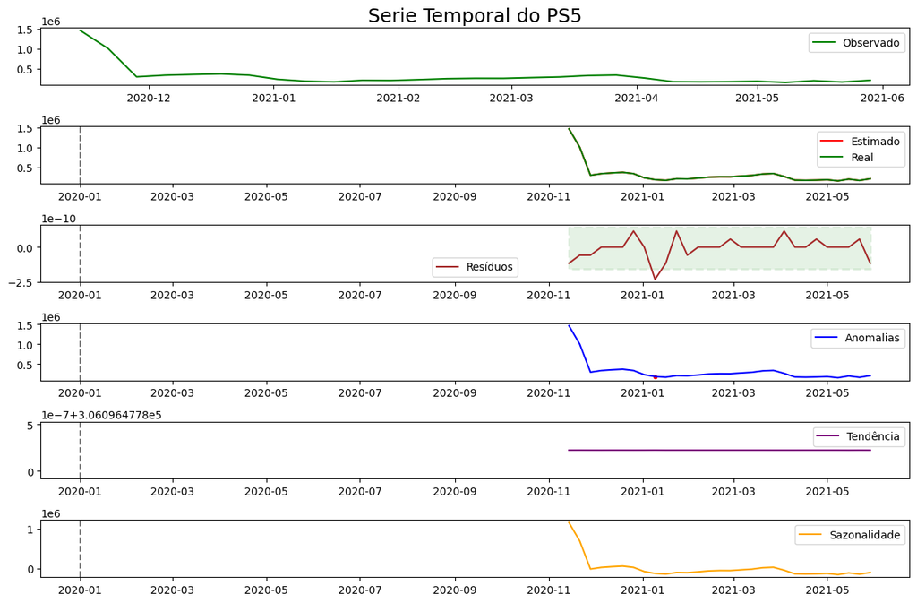

```
    Teste de R2 (Erro quadratico Séries): 0.9289100149362038
    Conclusão: Aproximação Boa
```

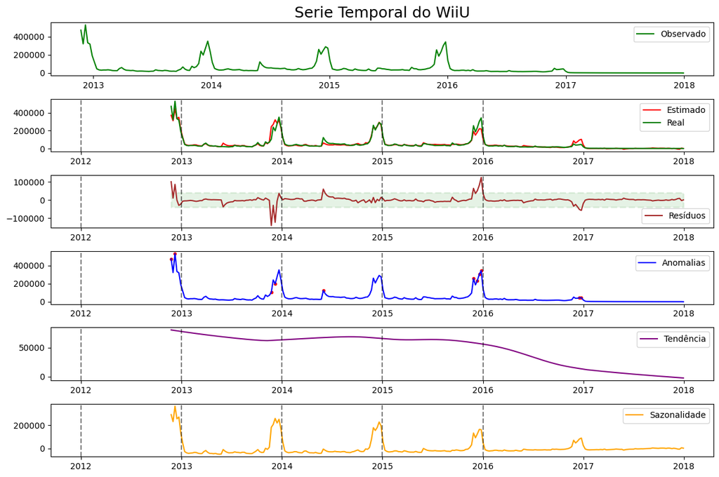

```
    Teste de R2 (Erro quadratico Séries): 0.8584414206710985
    Conclusão: Aproximação Boa
```

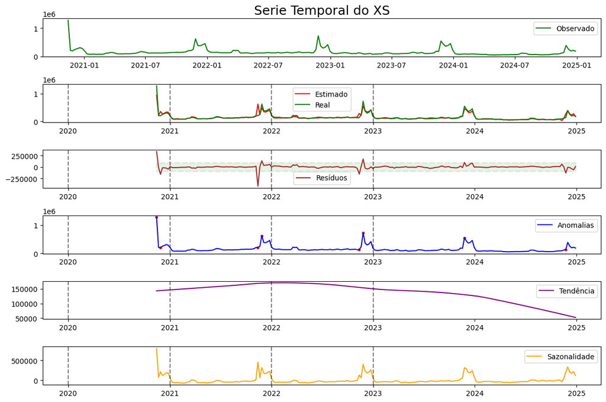

```
    Teste de R2 (Erro quadratico Séries): 0.926430211649431
    Conclusão: Aproximação Boa
```

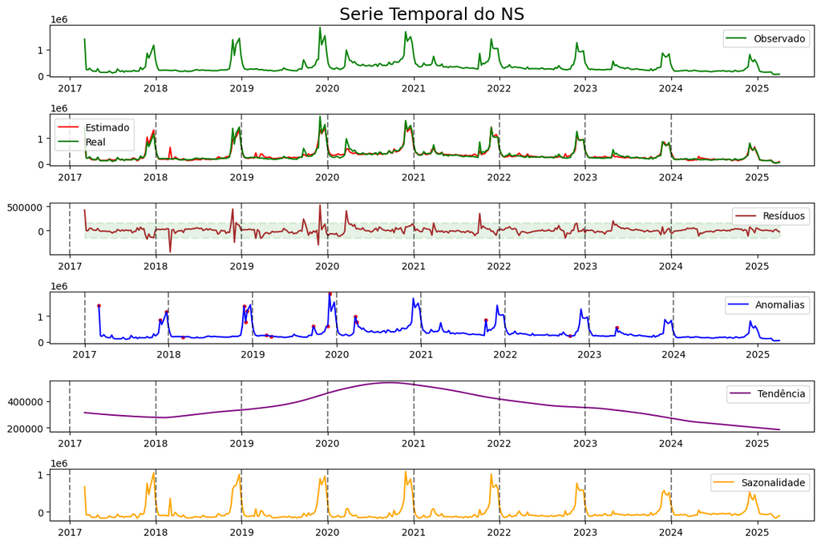

```
    Teste de R2 (Erro quadratico Séries): 0.8869195827579259
    Conclusão: Aproximação Boa
```

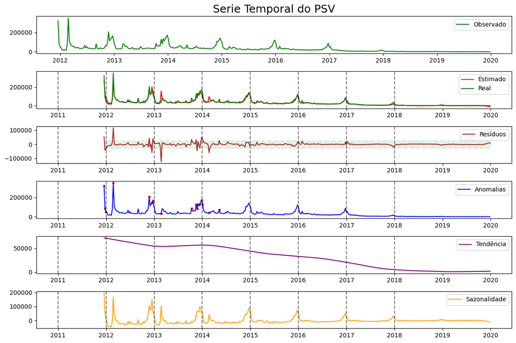

```
    Teste de R2 (Erro quadratico Séries): 0.9204975069207201
    Conclusão: Aproximação Boa
```

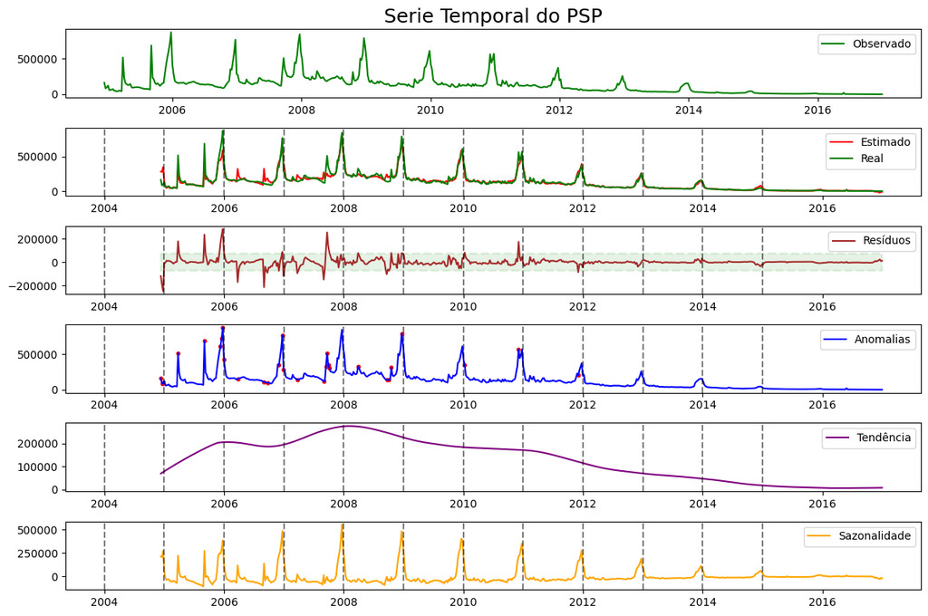

```
    Teste de R2 (Erro quadratico Séries): 0.9144758846871105
    Conclusão: Aproximação Boa
```

```python
for console in consoles:
        actual_series = df[console].dropna()
        actual_series = actual_series[actual_series != 0]
        decomposition = STL(actual_series, period=52).fit()

        date_min = actual_series.index.min().year
        date_max = actual_series.index.max().year

        plt.figure(figsize=(12, 8))
        plt.subplot(611)
        plt.title(f'Serie Temporal do {console}', fontsize=18)
        plt.plot(actual_series,color='green', label='Observado')
        plt.legend()

        plt.subplot(612)
        ss_res = np.sum(decomposition.resid**2)
        ss_tot = np.sum((actual_series - np.mean(actual_series))**2)
        r2 = 1 - (ss_res / ss_tot)

        text_test = (
            f'Teste de R2 (Erro quadratico Séries): {r2}\n'
            f'Conclusão: {"Aproximação Insuficiente" if r2 < 0.8 else "Aproximação Boa"}'
        )

        print(text_test)
        estimated = decomposition.trend + decomposition.seasonal
        plt.plot(estimated, color='red', label='Estimado')
        plt.plot(actual_series, color='green', label='Real')
        for year in range(date_min,date_max):
            plt.axvline(datetime(year,1,1), color='k', linestyle='--', alpha=0.5)
        plt.legend()

        plt.subplot(613)
        resid = decomposition.resid
        resid_mu = resid.mean()
        resid_dev = resid.std()

        dist = scipy.stats.t(df=len(resid)-1)
        critical_value = dist.ppf(0.975)

        lower = resid_mu - (resid_dev*critical_value)
        upper = resid_mu + (resid_dev*critical_value)
        plt.plot(resid, color='brown', label='Resíduos')
        plt.fill_between(resid.index,lower, upper, color='g', alpha=0.1, linestyle='--', linewidth=2)
        for year in range(date_min,date_max):
            plt.axvline(datetime(year,1,1), color='k', linestyle='--', alpha=0.5)

        plt.legend()


        plt.subplot(614)
        anomalies = actual_series[(resid < lower) | (resid > upper)]
        plt.plot(actual_series, color='blue', label='Anomalias')
        for year in range(date_min,date_max):
            plt.axvline(datetime(year,1,1), color='k', linestyle='--', alpha=0.5)

        plt.scatter(anomalies.index,anomalies, color='r', marker='.')
        plt.legend()

        plt.subplot(615)
        plt.plot(decomposition.trend, color='purple', label='Tendência')
        for year in range(date_min,date_max):
            plt.axvline(datetime(year,1,1), color='k', linestyle='--', alpha=0.5)
        plt.legend()

        plt.subplot(616)
        plt.plot(decomposition.seasonal, color='orange', label='Sazonalidade')
        for year in range(date_min,date_max):
            plt.axvline(datetime(year,1,1), color='k', linestyle='--', alpha=0.5)

        plt.legend()


        plt.tight_layout()
        plt.show()
```

[output not shown]

### Próximos Passos

É visível que o modelo de STL parece ser bom para previsões, e será isso que será feito!

## 📊 Análise Econômica Básica

Algumas estatísticas e analises com os dados encontrados.

```python
import pandas as pd
  import numpy as np
  import matplotlib.pyplot as plt
  import seaborn as sns
  from scipy import stats

  sales_df = pd.read_csv('../data/console_weekly_sales.csv')
  consoles_df = pd.read_csv('../data/console_stats.csv')

  sales_df['week'] = pd.to_datetime(sales_df['week'])

  merged_df = sales_df.merge(consoles_df, on='console')
```

### Análise Exploratória Inicial

#### Estatísticas Descritivas

Veremos o mercado de consoles trabalha com uma margem muito baixa entre preço e custo, e como isso varia conforme o custo e tipo do console. Além disso, é pssível observar que há uma grande volatilidade no numero de vendas semanais, podendo concluir em ciclos de vendas com picos e quedas muito altas.

##### Métricas por console

- Vendas médias semanais
- Vendas totais acumuladas (soma de todas as semanas)
- Desvio padrão das vendas (para medir volatibilidade)
- Margem bruta

```python
# Calcular estatísticas básicas
  console_metrics = sales_df.groupby('console')['sales'].agg(
      avg_weekly_sales=('mean'),
      total_sales=('sum'),
      sales_std=('std')
  ).reset_index()

  # Adicionar dados de preço e custo
  console_metrics = consoles_df[['console','type', '2025 price', '2025 cost']].merge(console_metrics, on='console')

  # Calcular margem bruta
  console_metrics['gross_margin'] = ((console_metrics['2025 price'] - console_metrics['2025 cost'])
                                    / console_metrics['2025 price'])

  # Formatando os resultados
  console_metrics = console_metrics.round({
      'avg_weekly_sales': 2,
      'total_sales': 0,
      'sales_std': 2,
      'gross_margin': 3
  }).rename(columns={
      '2025 price': 'preco_lancamento_ajustado',
      '2025 cost': 'custo_ajustado',
      'avg_weekly_sales': 'vendas_media_semanal',
      'total_sales': 'vendas_totais',
      'sales_std': 'volatilidade_vendas',
      'gross_margin': 'margem_bruta'
  })

  print("Métricas por Console:")
  display(console_metrics)
```

```
  Métricas por Console:
```

|  | console | type | preco_lancamento_ajustado | custo_ajustado | vendas_media_semanal | vendas_totais | volatilidade_vendas | margem_bruta |
| --- | --- | --- | --- | --- | --- | --- | --- | --- |
| 0 | DS | portable | 253.93 | 169.30 | 324253.00 | 154020176 | 330254.08 | 0.333 |
| 1 | PSP | portable | 409.35 | 311.12 | 130989.85 | 82523607 | 133501.14 | 0.240 |
| 2 | Wii | static | 396.56 | 250.64 | 213510.02 | 101630770 | 274957.99 | 0.368 |
| 3 | X360 | static | 489.61 | 556.74 | 135653.78 | 85733192 | 177178.37 | -0.137 |
| 4 | PS3 | static | 791.57 | 1276.98 | 150172.46 | 87400374 | 161609.19 | -0.613 |
| 5 | 3DS | portable | 355.41 | 142.17 | 133934.31 | 75940755 | 172940.04 | 0.600 |
| 6 | WiiU | static | 416.47 | 250.72 | 50787.19 | 13560180 | 77356.12 | 0.398 |
| 7 | PS4 | static | 547.74 | 523.03 | 201374.69 | 117200071 | 234239.43 | 0.045 |
| 8 | XOne | static | 685.02 | 646.58 | 121760.33 | 57957918 | 171904.59 | 0.056 |
| 9 | PSV | portable | 346.83 | 222.86 | 31272.12 | 13134292 | 38100.04 | 0.357 |
| 10 | NS | portable | 390.09 | 335.30 | 354463.84 | 149938206 | 284283.06 | 0.140 |
| 11 | XS | static | 369.46 | 369.46 | 146267.65 | 31886347 | 126120.36 | 0.000 |
| 12 | PS5 | static | 616.59 | 556.04 | 289134.65 | 8963174 | 273148.24 | 0.098 |

##### Métricas do mercado

- Vendas médias semanais
- Vendas totais acumuladas (soma de todas as semanas)
- Desvio padrão das vendas (para medir volatibilidade)
- Margem bruta

```python
# Calcular métricas agregadas
  total_revenue = (console_metrics['preco_lancamento_ajustado'] * console_metrics['vendas_totais']).sum()
  total_cost = (console_metrics['custo_ajustado'] * console_metrics['vendas_totais']).sum()

  market_metrics = {
      'vendas_media_semanal_mercado': sales_df['sales'].mean(),
      'vendas_totais_mercado': console_metrics['vendas_totais'].sum(),
      'volatilidade_mercado': sales_df.groupby('week')['sales'].sum().std(),
      'margem_bruta_mercado': (total_revenue - total_cost) / total_revenue
  }

  # Formatando para DataFrame
  with pd.option_context('display.float_format', '{:.2f}'.format):
      market_metrics = pd.DataFrame(
          list(market_metrics.items()),
          columns=['metric', 'value']
      )
      # Ajustar decimais específicos
      market_metrics['value'] = market_metrics.apply(
          lambda x: f"{x['value']:,.0f}" if 'totais' in x['metric'] else f"{x['value']:.3f}",
          axis=1
      )

  print("\nMétricas do Mercado:")
  display(market_metrics)
```

```
  Métricas do Mercado:
```

|  | metric | value |
| --- | --- | --- |
| 0 | vendas_media_semanal_mercado | 169560.315 |
| 1 | vendas_totais_mercado | 979,889,062 |
| 2 | volatilidade_mercado | 461350.868 |
| 3 | margem_bruta_mercado | 0.049 |

##### Métricas por Geração

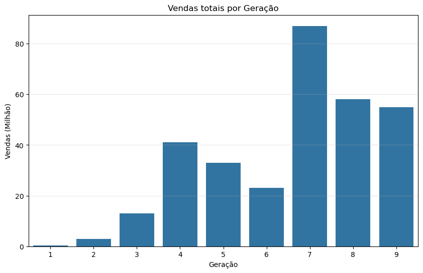

```python
gens_df = pd.read_csv('../data/companys.csv')

  # Calculando média de unidades vendidas
  units_by_gen = gens_df.groupby('Generation')['Units sold (million)'].median()

  # Gráfico de vendas por geração
  plt.figure(figsize=(10, 6))
  sns.barplot(data=units_by_gen)
  plt.title('Vendas totais por Geração')
  plt.ylabel('Vendas (Milhão)')
  plt.xlabel('Geração')
  plt.grid(axis='y', alpha=0.3)
  plt.show()
```

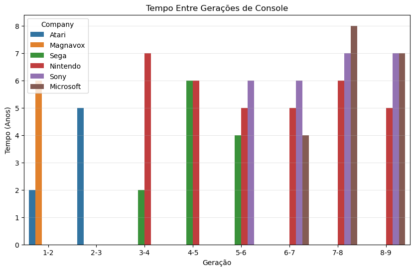

```python
# Adicionar coluna que guarda diferenças entre anos de lançamento
  console_differences = gens_df.groupby('Company')['Released Year'].diff()
  gens_df['Time Since Last Release'] = console_differences

  # Ordenando por geração
  consoles_by_gen = gens_df.dropna().sort_values(['Generation']).astype({'Time Since Last Release': int, 'Generation': str})

  # Renomeando a coluna Generations pra representar os intervalos entre gerações
  consoles_by_gen['Generation'] = consoles_by_gen['Generation'].apply(lambda x: str(int(x) - 1) + "-" + x)

  # Gráfico de tempo entre gerações
  plt.figure(figsize=(10, 6))
  sns.barplot(data=consoles_by_gen, x='Generation', y='Time Since Last Release', hue='Company')
  plt.title('Tempo Entre Gerações de Console')
  plt.ylabel('Tempo (Anos)')
  plt.xlabel('Geração')
  plt.grid(axis='y', alpha=0.3)
  plt.show()
```

##### Análise de sobrevivência dos consoles

Considerando um mínimo semanal de vendas, analizamos quanto tempo demorou para que as vendas semanais de cada console caíssem abaixo desse mínimo.

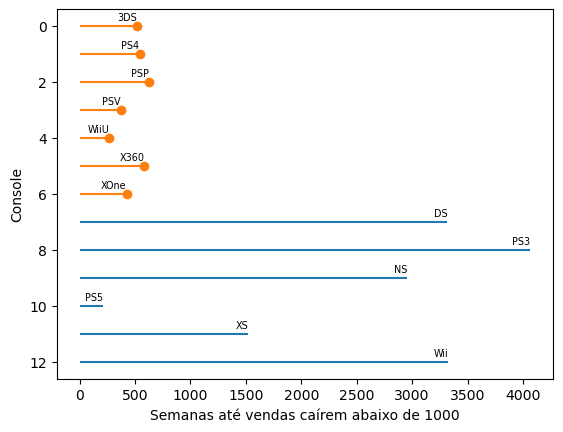

```python
min_sales = 1000

  # Modela quando as vendas caem abaixo do mínimo
  sales_df['sales dropped'] = (sales_df['sales'] < min_sales).astype(int)
  sales_df['time until drop'] = sales_df.groupby('console')['week'].rank(method='first')

  # Pra cada console, encontra a semana na qual as vendas caíram abaixo do mínimo
  failed = (sales_df[(sales_df['sales dropped'] == 1) & (sales_df['sales'] > 0)]
                   .groupby('console')
                   .first()
                   .reset_index()[['console', 'time until drop']])

  # Junta os consoles cujas vendas nunca caíram abaixo do mínimo
  never_failed = list(set(sales_df['console']) - set(failed['console']))
  never_failed_df = pd.DataFrame({
      'console': never_failed,
      'time until drop': ((sales_df.groupby('console')['week'].max() - sales_df.groupby('console')['week'].min()).dt.days)[never_failed].values
  })

  # Combina ambos datasets
  survival_data = pd.concat([failed, never_failed_df]).reset_index()
  survival_data['event occurred'] = survival_data['console'].isin(sales_df[sales_df['sales dropped'] == 1]['console']).astype(int)

  # Função de gráfico de tempo de vida
  def plot_lifelines(obs):
      for y, row in obs.iterrows():
          end = row['time until drop']

          if row['console'] in never_failed:
              # Ainda não caiu abaixo de 1000
              plt.hlines(y, 0, end, color='C0')
              plt.text(end, y - 0.3, row['console'], ha='right', va='center', size='x-small')
          else:
              # Caiu abaixo de 1000
              plt.hlines(y, 0, end, color='C1')
              plt.text(end, y - 0.3, row['console'], ha='right', va='center', size='x-small')
              plt.plot(end, y, marker='o', color='C1')

      plt.xlabel('Semanas até vendas caírem abaixo de 1000')
      plt.ylabel('Console')
      plt.gca().invert_yaxis()

  # Gráfico de tempo de vida
  plot_lifelines(survival_data)
  plt.show()
```

Então, usamos o método de estimativa Kaplan-Meier para calcular a probabilidade de sobrevivência de um console; ou seja, a probabilidade das vendas continuarem acima do mínimo.

```python
# Junta os tempos de vida únicos t
  ts = survival_data['time until drop'].unique()
  ts.sort()

  at_risk = pd.Series(0, index=ts)

  # Vê quantos estão em risco em cada t
  for t in ts:
      k = (t <= survival_data['time until drop'])
      at_risk[t] = k.sum()

  dropped = pd.Series(0, index=ts)

  # Vê quantos consoles têm vendas caírem abaixo do mínimo em cada t
  for t in ts:
      k = (survival_data['event occurred'] == 1) & (t == survival_data['time until drop'])
      dropped[t] = k.sum()

  # Fazendo dataframe de tempos de vida
  tempovida_d = dict(dropped=dropped,
           at_risk=at_risk)
  tempovida_df = pd.DataFrame(tempovida_d, index=ts)

  # Calculando risco
  tempovida_df['hazard'] = tempovida_df['dropped'] / tempovida_df['at_risk']

  # Probabilidade de sobrevivência (probabilidade de evento não ocorrer em todo t até o t atual)
  tempovida_df['surv'] = (1 - tempovida_df['hazard']).cumprod()

  display(tempovida_df)
```

|  | dropped | at_risk | hazard | surv |
| --- | --- | --- | --- | --- |
| 210.0 | 1 | 13 | 0.076923 | 0.923077 |
| 267.0 | 1 | 12 | 0.083333 | 0.846154 |
| 370.0 | 1 | 11 | 0.090909 | 0.769231 |
| 425.0 | 1 | 10 | 0.100000 | 0.692308 |
| 518.0 | 1 | 9 | 0.111111 | 0.615385 |
| 541.0 | 1 | 8 | 0.125000 | 0.538462 |
| 585.0 | 1 | 7 | 0.142857 | 0.461538 |
| 629.0 | 1 | 6 | 0.166667 | 0.384615 |
| 1519.0 | 1 | 5 | 0.200000 | 0.307692 |
| 2954.0 | 0 | 4 | 0.000000 | 0.307692 |
| 3318.0 | 0 | 3 | 0.000000 | 0.307692 |
| 3325.0 | 0 | 2 | 0.000000 | 0.307692 |
| 4067.0 | 0 | 1 | 0.000000 | 0.307692 |

O gráfico da função de sobrevivência em função do tempo é:

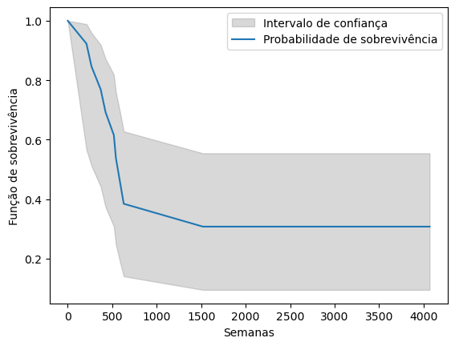

```python
from lifelines import KaplanMeierFitter
  kmf = KaplanMeierFitter()

  # Fazendo o intervalo de confiança da estimação Kaplan-Meier
  kmf.fit(survival_data['time until drop'], survival_data['event occurred'])
  ci = kmf.confidence_interval_survival_function_

  low, high = np.transpose(ci.values)

  # Gráfico da sobrevivência
  plt.fill_between(ci.index, low, high, color='gray', alpha=0.3)
  kmf.survival_function_.plot(ax=plt.gca())
  plt.legend(['Intervalo de confiança', 'Probabilidade de sobrevivência'])
  plt.ylabel('Função de sobrevivência')
  plt.xlabel('Semanas')

  plt.show()
```

##### Relação preço, custo e margem bruta

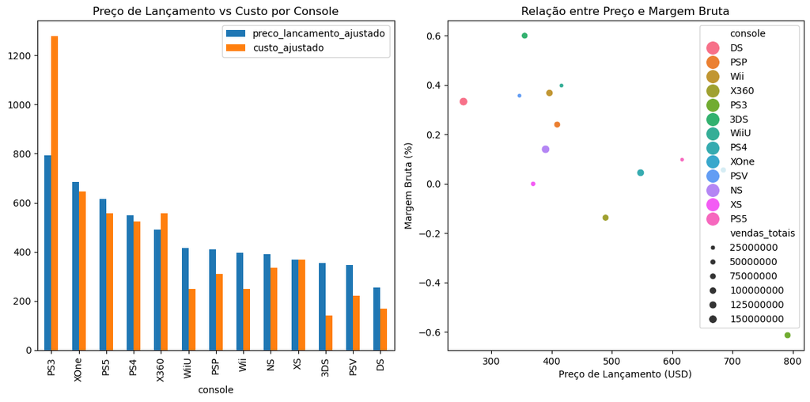

```
  Correlação Margem-Vendas: -0.07, p-value: 0.8148
```

```python
plt.figure(figsize=(12, 6))

  # Gráfico de Barras Comparativas
  ax = plt.subplot(1,2,1)
  console_metrics.sort_values('preco_lancamento_ajustado', ascending=False).plot(
      x='console',
      y=['preco_lancamento_ajustado', 'custo_ajustado'],
      kind='bar',
      ax=ax,
      title='Preço de Lançamento vs Custo por Console'
  )

  # Gráfico de Dispersão Margem Bruta
  ax = plt.subplot(1,2,2)
  sns.scatterplot(
      x='preco_lancamento_ajustado',
      y='margem_bruta',
      size='vendas_totais',
      hue='console',
      data=console_metrics,
      s=200,
      ax=ax
  )
  plt.title('Relação entre Preço e Margem Bruta')
  plt.xlabel('Preço de Lançamento (USD)')
  plt.ylabel('Margem Bruta (%)')

  plt.tight_layout()
  plt.show()

  # Correlação
  margin_corr = console_metrics.groupby('console')[['margem_bruta', 'vendas_totais']].mean().reset_index()
  corr, p_value = stats.pearsonr(margin_corr['margem_bruta'], margin_corr['vendas_totais'])
  print(f"Correlação Margem-Vendas: {corr:.2f}, p-value: {p_value:.4f}")
```

##### Relação entre Vendas e Tipo de Console

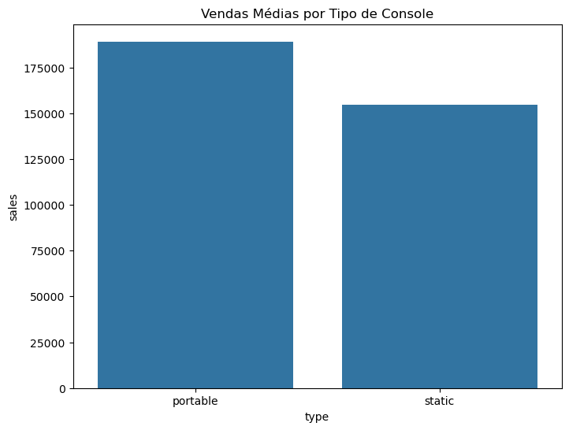

```python
# Calcular vendas médias por tipo
  type_sales = merged_df.groupby('type')['sales'].mean().reset_index()

  # Gráfico de barras
  plt.figure(figsize=(8,6))
  sns.barplot(x='type', y='sales', data=type_sales)
  plt.title('Vendas Médias por Tipo de Console')
  plt.show()
```

##### Curva de Demanda para Consoles (Usando Preço dos Consoles)

```
  Elasticidade-Preço da Demanda: 0.080
  Intervalo de Confiança 95%: (-1.376, 1.535)
  Significância Estatística (p-value): 0.9060
```

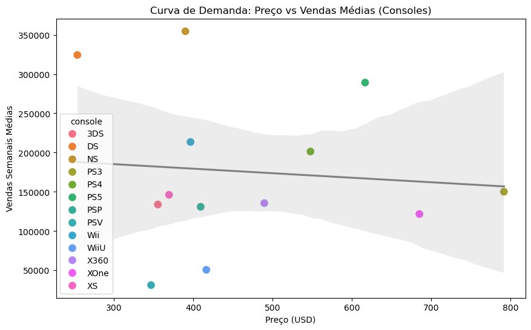

```python
# Criar coluna de preço vigente
  merged_df['current_price'] = merged_df['2025 price']

  # Agrupar por preço e calcular vendas médias
  demand_curve = merged_df.groupby(['console', 'current_price'])['sales'].mean().reset_index()

  # Modelagem linear (elasticidade-preço)
  import statsmodels.formula.api as smf

  model = smf.ols('np.log(sales) ~ np.log(current_price)', data=demand_curve).fit()
  elasticidade = model.params['np.log(current_price)']
  intervalo_confianca = model.conf_int().loc['np.log(current_price)']
  p_value = model.pvalues['np.log(current_price)']

  # Resultados
  print(f'Elasticidade-Preço da Demanda: {elasticidade:.3f}')
  print(f'Intervalo de Confiança 95%: ({intervalo_confianca[0]:.3f}, {intervalo_confianca[1]:.3f})')
  print(f'Significância Estatística (p-value): {p_value:.4f}')

  # Modelo com interação por tipo
  model_tipo = smf.ols('np.log(sales) ~ np.log(current_price) * type',
                      data=demand_curve.merge(consoles_df, on='console')).fit()

  # Gráfico da curva
  plt.figure(figsize=(10,6))
  sns.scatterplot(x='current_price', y='sales', hue='console', data=demand_curve, s=100)
  sns.regplot(x='current_price', y='sales', data=demand_curve, scatter=False, color='grey')
  plt.title('Curva de Demanda: Preço vs Vendas Médias (Consoles)')
  plt.xlabel('Preço (USD)')
  plt.ylabel('Vendas Semanais Médias')
  plt.show()
```

#### Estrutura de Mercado

Nesse sentido, pensamos que o mercado dos consoles é um oligopólio, devido ao fato dessas 3 empresas dominarem o mercado e venderam produtos similares.

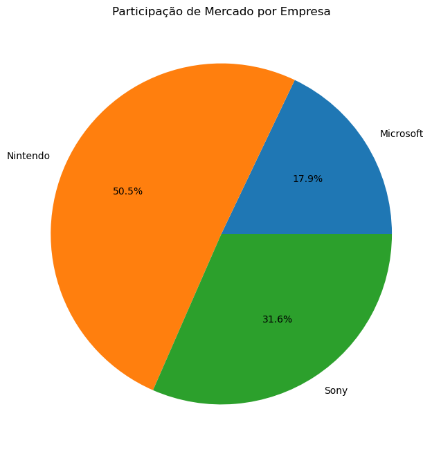

```python
# Calcular vendas totais por empresa
  market_share = merged_df.groupby('company')['sales'].sum().reset_index()
  market_share['share'] = (market_share['sales'] / market_share['sales'].sum()) * 100

  # Gráfico de pizza
  plt.figure(figsize=(8,8))
  plt.pie(market_share['share'], labels=market_share['company'], autopct='%1.1f%%')
  plt.title('Participação de Mercado por Empresa')
  plt.show()
```

##### Índice Herfindahl-Hirschman (HHI)

É uma medida comum de concentração de mercado e é usado para determinar a competitividade do mercado. Um mercado com um HHI abaixo de 1.500 é considerado competitivo, um HHI de 1.500 a 2.500 é moderadamente concentrado e um HHI de 2.500 ou superior é altamente concentrado.

Note abaixo que segundo o índice, esse mercado é altamente concentrado, o que leva uma atenção especial, pois as empresas tem um alto poder de mercado.

```python
# Calcular HHI
  market_share['squared_share'] = (market_share['share']) ** 2
  hhi = market_share['squared_share'].sum()
  print(f"Índice HHI: {hhi:.2f}")
```

```
  Índice HHI: 3869.68
```

### Limitações e Melhorias

- Dados de Preços: A análise de demanda fica limitada pela escassez de variação de preços.
- Fatores Omitidos: A demanda é influenciada por variáveis não disponíveis (e.g., marketing, lançamento de jogos).
- Endogeneidade: O preço pode ser ajustado em resposta às vendas, criando viés.

#### Próximos Passos que Pensamos

- Coletar dados históricos mensais de preços dos consoles
- Incluir métricas de jogos (attach rate, títulos lançados)
- Adicionar dados macroeconômicos (PIB, taxa de desemprego)

## 🤔 Primeiras Perguntas e Hipóteses

### Análise do Número de Venda dos Consoles de cada Empresa com base na Região

Nessa análise nosso intuito é saber como as diferentes regiões, com suas diferentes características de mercado, influenciam a venda de alguns consoles. Usaremos os dados disponíveis [Platform Totals - VGChartz](https://www.vgchartz.com/charts/platform_totals/Hardware.php).

#### Regiões

A plataforma coletou esses dados desde 2004 separando as vendas nas regiões de north_america (América do Norte), europe (Europa), japan (Japão) e other (Outros).

Filtramos para que possamos lidar somente com consoles que tenham números de vendas registrados para as 4 regiões.

#### Empresas

As empresas de jogos com as quais lidaremos são: Atari, Microsoft, Nintendo, SEGA e Sony.

Atari, SEGA e Microsoft tem 4 ou menos consoles registrados cada, o que pode acabar gerando um viés maior em suas estatísticas, por representarem uma parcela bem menor do total.

```python
import pandas as pd
  import matplotlib.pyplot as plt
  import numpy as np
  import math
  from io import StringIO
  from datetime import datetime
```

```python
df_region = (pd.read_csv("../data/console_region.csv")).sort_values(by='company')
  company = df_region.groupby('company').sum(numeric_only = True)

  regions = ['north_america', 'europe', 'japan', 'other']
  companies = ['Atari', 'Microsoft', 'Nintendo', 'SEGA', 'Sony']
```

### Como testaremos?

Queremos agora testar como cada região influencia a venda de cada empresa:

> Para tal vamos pegar o número de vendas da empresa E na região R e dividir pelas vendas totais da mesma empresa.

> Ao mesmo tempo, vamo pegar o número de vendas que não correspondem a empresa E na região R e dividir pelas vendas totais de todos os consoles, menos o da empresa E.

> Faremos um teste de hipótese de comparação de proporções populacionais para verificar se são iguais

#### Teste de Hipótese

O teste de hipótese deve ser feito da seguinte forma: $$ \begin{aligned} p_1 &- \text{Proporção de vendas na região R da empresa E} \\ \\ n_1 &- \text{Total de vendas da empresa E} \\ \\ m_1 &- \text{Número de vendas da empresa E na região R} \\ \\ p_1 &= \frac{m_1}{n_1} \\ \\ p_2 &- \text{Proporção de vendas na região R sem a empresa E} \\ \\ n_2 &- \text{Total de vendas sem a empresa E} \\ \\ m_2 &- \text{Número de vendas sem a empresa E na região R} \\ \\ p_2 &= \frac{m_2}{n_2} \\ \\ \bar{p} &= \frac{m_1 + m_2}{n_1 + n_2} \\ \\ Z_{obs} &= \frac{p_1 - p_2}{\sqrt{\bar{p}(1 - \bar{p})(\frac{1}{n_1} + \frac{1}{n_2})}} \sim N(0, 1) \end{aligned} $$

#### Hipóteses

Ou seja, rejeitaremos a Hipótese Nula se o valor absoluto de Z_obs for maior que 1.96. Isso se deve ao fato de P(Z > 1.96) = 0.025, se juntarmos com P(Z < -1.96) = 0.025 temos α.

#### Teste com a Nintendo no Japão

Vamos primeiramente analisar o comportamento dos consoles da Nintendo na região do Japão. Tradicionalmente espera-se que a região impacte positivamente as vendas, já que a empresa é da região e grande parte de seus fãs são japoneses.

Nesse caso específico usaremos

$$ \begin{aligned} &H_0: p_1 \leq p_2 \quad \text{(Hipótese Nula)} \\ &H_1: p_1 > p_2 \quad \text{(Hipótese Alternativa, unilateral à direita)} \\ &\alpha = 0.05 \quad \text{(Nível de significância)} \end{aligned} $$

Rejeitaremos a Hipótese Nula se Z_obs for maior que 1.645

```python
nintendo = company.loc['Nintendo']
        not_nintendo = company.loc['Total'] - nintendo
        n1 = nintendo.get('global')
        n2 = not_nintendo.get('global')
        m1 = nintendo.get('japan')
        m2 = not_nintendo.get('japan')
        p1 = m1/n1
        p2 = m2/n2
        p0 = (m1 + m2)/(n1 + n2)
        z = (p1 - p2) / math.sqrt(p0 * (1 - p0) * (1/n1 + 1/n2))
        z.round(3)
```

```
6.649
```

#### Resultado

> Z_obs = 6.649

> Z_obs > 1.645

Conclusão: Rejeitamos a Hipótese Nula de que a proporção de consoles da Nintendo vendidos no Japão em comparação com os que não são da Nintendo vendidos no Japão é menor ou igual.

#### Continuação

Expandiremos o teste para todas as empresas com todas as regiões. Criaremos uma tabela para tal que conterá todos os Z_obs

```python
matrix = []
        for c in companies:
            vector = []
            for r in regions:
                in_company = company.loc[c]
                not_in_company = company.loc['Total'] - in_company
                n1 = in_company.get('global')
                n2 = not_in_company.get('global')
                m1 = in_company.get(r)
                m2 = not_in_company.get(r)
                p1 = m1/n1
                p2 = m2/n2
                p0 = (m1 + m2)/(n1 + n2)
                vector.append(((p1 - p2) / math.sqrt(p0 * (1 - p0) * (1/n1 + 1/n2))).round(3))
            matrix.append(vector)
        matrix
        proportions = pd.DataFrame(data=matrix, index=companies ,columns=regions)
        proportions
```

|  | north_america | europe | japan | other |
| --- | --- | --- | --- | --- |
| Atari | 4.197 | -2.225 | -1.408 | -1.593 |
| Microsoft | 4.688 | -0.646 | -6.372 | 1.280 |
| Nintendo | 0.623 | -1.900 | 6.649 | -6.103 |
| SEGA | -0.261 | -0.217 | -1.201 | 2.120 |
| Sony | -4.760 | 3.090 | -1.895 | 5.124 |

#### Conclusão Geral

Com base na tabela, as Hipóteses Nulas são descartadas se o valor absoluto for maior do que 1.96. Para as descartadas, levamos em conta o teste unilateral correspondente, para ter a informação específica de como a região afeta as vendas (positiva ou negativamente):

- Atari: É afetada positivamente pela America do Norte e negativamente pela Europa
- Microsoft: É afetada positivamente pela America do Norte e negativamente pelo Japão
- Nintendo: É afetada positivamente pelo Japão e negativamente por "Outros"
- SEGA: É afetada positivamente por "Outros"
- Sony: É afetada negativamente pela America do Norte e positivamente pela Europa e por "Outros"

#### Observações

> Região "Outros": Nintendo X Sony

> Microsoft: Japão x América do Norte

> Nintendo: Dominância no Japão

### Análise Profunda do Caso Nintendo no Japão

Com o teste de hipótese acima, é comum acreditar que somente com o nome da marca, os consoles da Nintendo vão vender melhor no Japão. Isso pode até ser verdade, mas não é garantido. Pode ser, por exemplo, que metade dos consoles da Nintendo venda MUITO melhor no Japão enquanto os outros fiquem na média ou ainda abaixo dela.

Para termos mais informações sobre esse caso e também um pouco sobre como funciona o mercado japonês, testaremos com cada um dos consoles da Nintendo.

Com isso também podemos achar algumas anomalias dentre os consoles da empresa

```python
nintendo_consoles = df_region[(df_region.get("company") == "Nintendo")]
  nintendo_consoles = nintendo_consoles.drop(columns=["company", "north_america", "europe", "other"])
  nintendo_consoles = nintendo_consoles.set_index('console')
  consoles = nintendo_consoles.index
  nintendo_array = []
  not_nintendo = company.loc['Total'] - company.loc['Nintendo']
  for c in consoles:
      in_console = nintendo_consoles.loc[c]
      n1 = in_console.get('global')
      n2 = not_nintendo.get('global')
      m1 = in_console.get('japan')
      m2 = not_nintendo.get('japan')
      p1 = m1/n1
      p2 = m2/n2
      p0 = (m1 + m2)/(n1 + n2)
      nintendo_array.append(((p1 - p2) / math.sqrt(p0 * (1 - p0) * (1/n1 + 1/n2))).round(3))

  nintendo_consoles = nintendo_consoles.assign(japan_z_obs=nintendo_array)
  nintendo_consoles
```

| console | japan | global | japan_z_obs |
| --- | --- | --- | --- |
| Nintendo 64 | 5.54 | 32.93 | 0.865 |
| Super Nintendo Entertainment System | 17.17 | 49.10 | 4.700 |
| Nintendo 3DS | 24.67 | 75.94 | 5.082 |
| Game Boy Advance | 16.96 | 81.51 | 2.344 |
| Nintendo Entertainment System | 19.35 | 61.91 | 4.394 |
| Nintendo Wii | 12.77 | 101.63 | 0.216 |
| Nintendo Wii U | 3.33 | 13.56 | 1.430 |
| Game Boy | 32.47 | 118.69 | 4.649 |
| Nintendo Switch | 35.58 | 150.25 | 3.946 |
| Nintendo DS | 32.99 | 154.02 | 3.257 |
| GameCube | 4.04 | 21.74 | 0.957 |

#### Conclusão Parcial

É interessante notar que todos os consoles da Nintendo tem uma uma mudança neutra ou positiva se estão no Japão.

Dos 11 consoles testados da empresa, 7 são influenciados positivamente pelo mercado japonês.

Isso indica com grande confiança que, só de ser da Nintendo os consoles tem grande chance de serem afetados positivamente em território japonês. Não se trata somente de um caso ridiculamente grande de estouro no Japão, é um padrão seguido pelos produtos da empresa.

Isso colabora com a ideia geral e popular de que a Nintendo tem uma grande legião fixa de fãs. Enquanto algumas franquias vem e vão, a Nintendo consolidou sua base e não parece querer abandoná-la.

#### Nintendo x Nintendo

Nessa sessão vamos analisar cada console da Nintendo com os outros consoles da própria Nintendo.

Dessa forma vamos identificar as anomalias (além dos que não são afetados pelo mercado japonês do caso acima) e tentar traçar um padrão entre elas.

```python
nintendo_x_nintendo = []
  for c in consoles:
      in_console = nintendo_consoles.loc[c]
      n1 = in_console.get('global')
      n2 = nintendo_consoles.get('global').sum() - n1
      m1 = in_console.get('japan')
      m2 = nintendo_consoles.get('japan').sum() - m1
      p1 = m1/n1
      p2 = m2/n2
      p0 = (m1 + m2)/(n1 + n2)
      nintendo_x_nintendo.append(((p1 - p2) / math.sqrt(p0 * (1 - p0) * (1/n1 + 1/n2))).round(3))

  nintendo_consoles = nintendo_consoles.assign(nintendo_z_obs=nintendo_x_nintendo)
  nintendo_consoles
```

| console | japan | global | japan_z_obs | nintendo_z_obs |
| --- | --- | --- | --- | --- |
| Nintendo 64 | 5.54 | 32.93 | 0.865 | -0.957 |
| Super Nintendo Entertainment System | 17.17 | 49.10 | 4.700 | 1.895 |
| Nintendo 3DS | 24.67 | 75.94 | 5.082 | 1.865 |
| Game Boy Advance | 16.96 | 81.51 | 2.344 | -0.664 |
| Nintendo Entertainment System | 19.35 | 61.91 | 4.394 | 1.433 |
| Nintendo Wii | 12.77 | 101.63 | 0.216 | -2.829 |
| Nintendo Wii U | 3.33 | 13.56 | 1.430 | 0.067 |
| Game Boy | 32.47 | 118.69 | 4.649 | 0.984 |
| Nintendo Switch | 35.58 | 150.25 | 3.946 | -0.034 |
| Nintendo DS | 32.99 | 154.02 | 3.257 | -0.761 |
| GameCube | 4.04 | 21.74 | 0.957 | -0.577 |

#### Conclusão Final

Com a nova tabela, podemos tirar novas conclusões e hipóteses interessantes.

Primeiramente, nenhum dos valores de console parece ser afetador mais positivamente pelo Japão do que a média da Nintendo em si.

Apesar disso, podemos notar um que é afetado negativamente em comparação a média.

Esse console anômalo é o Wii.

É um resultado que faz sentido ao pensar na febre que foi esse console, que vendeu bem até mesmo em países que a Nintendo não tem tanta influência direta.

O Wii, na verdade é o sétimo console mais vendido de todos os tempos¹, enquanto seus competidores de geração, Play Station 3 e Xbox 360 ocupam a oitava e nona posição respectivamente¹.

A febre que foi o console se deve também pela inovação que trouxe os famosos controles de movimento. (Reação a Incentivos)

Em números brutos, o GameBoy, Switch e DS, também da Nintendo, venderam mais que o Wii¹. Apesar disso, a venda deles não foi afetada negativamente no Japão e entram no grupo dos 7 afetados positivamente no país. Nesse caso, a febre global parece ter crescido juntamente com a situação nacional do console.

1: [10 consoles mais vendidos na história](https://olhardigital.com.br/2024/01/24/games-e-consoles/os-10-consoles-mais-vendidos-na-historia/)

#### Reflexão de Mercado

O mercado de consoles aparenta estar entre um oligopólio e uma concorrência monopolística. A entrada e saída não é livre, dada a dificuldade de produção de um console e o custo de consolidação no mercado. Apesar disso, os produtos são diferenciáveis, cada um oferecendo sua própria inovação e vantagens, como podemos ver no caso do Wii, que foge da regra até dentro de sua própria empresa.

Com essas análises, também fica mais fácil de prever onde o marketing de um produto tende a gerar mais resultado. É praticamente inútil para a Microsoft anunciar seus produtos no Japão. O país afeta tão negativamente suas vendas que o custo de se firmar no mercado de videogames lá pode ultrapassar o possível retorno desse investimento.

A análise também pode apresentar características do mercado local que podem passar despercebidas. Um exemplo é o aparente forte nacionalismo japonês quanto as suas empresas, preferindo comprar produtos nacionais a estrangeiros.